# Overview of Probability Distributions

## Introduction

- On Monday:
  - Refresher on probability theory
  - What does each distribution do?
    - beta $\to$ outcomes limited to [0, 1]
    - binomial $\to$ binary outcomes
    - gamma $\to$ continuous & positive outcomes; skewed right
    - normal $\to$ continuous outcomes; mound-shaped & symmetric distribution
    - Poisson $\to$ count outcomes; skewed right
    - uniform $\to$ each outcome has equal probability; rectangular distribution
- Today: building up Bayesian analysis concepts

## R Packages Needed

- To follow today’s lecture, please load the following packages:
  - `tidyverse`
  - `janitor`
  - `bayesrules`

```r
library(tidyverse)
library(janitor)
library(bayesrules)
```

## Thinking Like a Bayesian

- Bayesian analysis involves updating beliefs based on observed data.

[interactive chart not shown]

## Thinking Like a Bayesian

- Bayesian analysis involves updating beliefs based on observed data.

[interactive chart not shown]

## Thinking Like a Bayesian

- Bayesian analysis involves updating beliefs based on observed data.

[interactive chart not shown]

## Thinking Like a Bayesian

- Bayesian analysis involves updating beliefs based on observed data.

[interactive chart not shown]

## Thinking Like a Bayesian

- This is the natural Bayesian knowledge-building process of:
  - acknowledging your preconceptions (prior distribution),

[interactive chart not shown]

## Thinking Like a Bayesian

- This is the natural Bayesian knowledge-building process of:
  - acknowledging your preconceptions (prior distribution),
  - using data (data distribution) to update your knowledge (posterior distribution),

[interactive chart not shown]

## Thinking Like a Bayesian

- This is the natural Bayesian knowledge-building process of:
  - acknowledging your preconceptions (prior distribution),
  - using data (data distribution) to update your knowledge (posterior distribution), and
  - repeating (posterior distribution $\to$ new prior distribution)

[interactive chart not shown]

## Thinking Like a Bayesian

- Bayesian and frequentist analyses share a common goal: to learn from data about the world around us.
  - Both Bayesian and frequentist analyses use data to fit models, make predictions, and evaluate hypotheses.
  - When working with the same data, they will typically produce a similar set of conclusions.
- Statisticians typically identify as either a “Bayesian” or “frequentist” …
  - We are not going to “take sides.”
  - We will see these as tools in our toolbox.

## Thinking Like a Bayesian

- **Bayesian probability:** the relative plausibility of an event. This considers prior belief.

[interactive chart not shown]

## Thinking Like a Bayesian

- **Frequentist probability:** the long-run relative frequency of a repeatable event. This does not consider prior belief.

[interactive chart not shown]

## Thinking Like a Bayesian

- The Bayesian framework depends upon prior information, data, and the balance between them.
  - The balance between the prior information and data is determined by the relative strength of each.

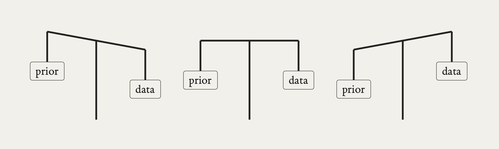

- When we have little data, our posterior can rely more on prior knowledge.
- As we collect more data, the prior can lose its influence.

## Thinking Like a Bayesian

- We can also use this approach to combine analysis results.

[interactive chart not shown]

## Thinking Like a Bayesian

- We will use an example to work through Bayesian logic.
- The Collins Dictionary named “fake news” the 2017 term of the year.
  - Fake, misleading, and biased news has proliferated along with online news and social media platforms which allow users to post articles with little quality control.
- We want to flag articles as “real” or “fake.”
- We’ll examine a sample of 150 articles which were posted on Facebook and fact checked by five BuzzFeed journalists (Shu et al. 2017).

## Thinking Like a Bayesian

- Information about each article is stored in the `fake_news` dataset in the `bayesrules` package.

```r
fake_news <- bayesrules::fake_news
print(colnames(fake_news))
```

```
 [1] "title"                   "text"
 [3] "url"                     "authors"
 [5] "type"                    "title_words"
 [7] "text_words"              "title_char"
 [9] "text_char"               "title_caps"
[11] "text_caps"               "title_caps_percent"
[13] "text_caps_percent"       "title_excl"
[15] "text_excl"               "title_excl_percent"
[17] "text_excl_percent"       "title_has_excl"
[19] "anger"                   "anticipation"
[21] "disgust"                 "fear"
[23] "joy"                     "sadness"
[25] "surprise"                "trust"
[27] "negative"                "positive"
[29] "text_syllables"          "text_syllables_per_word"
```

## Thinking Like a Bayesian

- Suppose that the most recent article posted to a social media platform is titled: *The president has a funny secret!*
  - Some features of this title probably set off some red flags.
  - For example, the usage of an exclamation point might seem like an odd choice for a real news article.
- In the dataset, what is the split of real and fake articles?

```r
fake_news %>% tabyl(type)
```

## Thinking Like a Bayesian

- In the dataset, what is the split of real and fake articles?

```r
fake_news %>% tabyl(type)
```

| type | n | percent |
| --- | --- | --- |
| fake | 60 | 0.4 |
| real | 90 | 0.6 |

## Thinking Like a Bayesian

- What does the data say?

```r
fake_news %>% tabyl(title_has_excl, type) %>%
  adorn_percentages("col") %>%
  adorn_pct_formatting(digits = 2) %>%
  adorn_ns()
```

## Thinking Like a Bayesian

- What does the data say?

```r
fake_news %>% tabyl(title_has_excl, type) %>%
  adorn_percentages("col") %>%
  adorn_pct_formatting(digits = 2) %>%
  adorn_ns()
```

| title_has_excl | fake | real |
| --- | --- | --- |
| FALSE | 73.33% (44) | 97.78% (88) |
| TRUE | 26.67% (16) | 2.22% (2) |

- 26.67% of fake news titles use ! vs 2.22% of real news titles use !

## Thinking Like a Bayesian

- We now have two pieces of contradictory information.
  - Our prior information suggested that incoming articles are most likely real.
  - However, the exclamation point data is more consistent with fake news.

[interactive chart not shown]

## Building a Bayesian Model

- Thinking like Bayesians, we know that balancing both pieces of information is important in developing a posterior understanding of whether the article is fake.
- Our fake news analysis studies two variables:
  - an article’s fake vs real status and
  - its use of exclamation points.
- We can represent the randomness in these variables using probability models.

## Building a Bayesian Model

- Let’s now formalize our prior understanding of whether the new article is fake.
- Based on our data, we saw that 40% of articles are fake and 60% are real.
  - Before reading the new article, there’s a 0.4 *prior* probability that it’s fake.

$$P\left[B\right] = 0.40 \text{ and } P\left[B^c\right] = 0.60$$

- Remember that a valid probability model must:
  1. account for all possible events
  2. assign prior probabilities to each event
  3. have probabilities that sum to 1

## Building a Bayesian Model

- Revisiting the contingency table for conditional probabilities,

| title_has_excl | fake | real |
| --- | --- | --- |
| FALSE | 73.3% (44) | 97.8% (88) |
| TRUE | 26.7% (16) | 2.2% (2) |

- If an article is fake ($B$), what is the probability that it uses exclamation points in the title?
- If an article is real ($B^c$), what is the probability that it uses exclamation points in the title?

## Building a Bayesian Model

- We have the following conditional probabilities:
  - If an article is fake, then there is about a 27% chance it uses exclamation points in the title.
    - $P[A|B]=0.2667$
  - If an article is real, then there is only a 2% chance it uses exclamation points in the title.
    - $P[A|B^c]=0.0222$
- Exclamation point usage is much more likely among fake news than real news.
  - We have evidence that the article is fake.

## Building a Bayesian Model

- Note that we know that the incoming article used exclamation points ($A$), but we do not actually know if the article is fake ($B$ or $B^c$).
- In this case, we compared $P[A|B]$ and $P[A|B^c]$ to ascertain the **relative likelihood** of observing $A$ under different scenarios. That is,
  - $L\left[B|A\right] = P\left[A|B\right]$ $\to$ the likelihood of fake given !
  - $L\left[B^c|A\right] = P\left[A|B^c\right]$ $\to$ the likelihood of real given !

## Building a Bayesian Model

| Event | *B* | *B<sup>c</sup>* | Total |
| --- | --- | --- | --- |
| Prior Probability | 0.4 | 0.6 | 1.0 |
| Likelihood | 0.2667 | 0.0222 | 0.2889 |

$$L\left[B|A\right] = P\left[A|B\right] \text{ and } L\left[B^c|A\right] = P\left[A|B^c\right]$$

- It is important for us to note that the likelihood function is *not* a probability function.
  - This is a framework to determine the relative compatibility of our exclamation point data with $B$ and $B^c$.

## Building a Bayesian Model

| Event | *B* (fake) | *B<sup>c</sup>* (real) | Total |
| --- | --- | --- | --- |
| Prior Probability | 0.4 | 0.6 | 1.0 |
| Likelihood | 0.2667 | 0.0222 | 0.2889 |

- The prior evidence suggested the article is most likely real,

$$P[B] = 0.4 < P[B^c] = 0.6$$

- The data, however, is more consistent with the article being fake,

$$L[B|A] = 0.2667 > L[B^c|A] = 0.0222$$

## Building a Bayesian Model

- We can summarize our probabilities in a table,

|  | $B$ | $B^c$ | Total |
| --- | --- | --- | --- |
| $A$ |  |  |  |
| $A^c$ |  |  |  |
| **Total** | 0.4 | 0.6 | 1 |

- As found earlier, $P[A|B] = 0.2667$ and $P[A|B^c]=0.0222$.
- Find $P[A \cap B]$.

## Building a Bayesian Model

- We can summarize our probabilities in a table,

|  | $B$ | $B^c$ | Total |
| --- | --- | --- | --- |
| $A$ |  |  |  |
| $A^c$ |  |  |  |
| **Total** | 0.4 | 0.6 | 1 |

- As found earlier, $P[A|B] = 0.2667$ and $P[A|B^c]=0.0222$.

$$\begin{align*}
P[A \cap B] &= P[A|B] \times P[B] \\
&= 0.2667 \times 0.4 \\
&= 0.1067
\end{align*}$$

## Building a Bayesian Model

- Here’s what we know,

|  | $B$ | $B^c$ | Total |
| --- | --- | --- | --- |
| $A$ | 0.1067 |  |  |
| $A^c$ |  |  |  |
| **Total** | 0.4 | 0.6 | 1 |

- As found earlier, $P[A|B] = 0.2667$ and $P[A|B^c]=0.0222$.
- Find $P[A^c \cap B]$.

## Building a Bayesian Model

- Here’s what we know,

|  | $B$ | $B^c$ | Total |
| --- | --- | --- | --- |
| $A$ | 0.1067 |  |  |
| $A^c$ |  |  |  |
| **Total** | 0.4 | 0.6 | 1 |

- As found earlier, $P[A|B] = 0.2667$ and $P[A|B^c]=0.0222$.

$$\begin{align*}
P[A^c \cap B] &= P[A^c|B] \times P[B] \\
&= \left(1-P[A|B]\right) \times P[B] \\
&= (1-0.2667) \times 0.4 \\
&= 0.2933
\end{align*}$$

## Building a Bayesian Model

- Here’s what we know,

|  | $B$ | $B^c$ | Total |
| --- | --- | --- | --- |
| $A$ | 0.1067 |  |  |
| $A^c$ | 0.2933 |  |  |
| **Total** | 0.4 | 0.6 | 1 |

- As found earlier, $P[A|B] = 0.2667$ and $P[A|B^c]=0.0222$.
- Find $P[A \cap B^c]$.

## Building a Bayesian Model

- Here’s what we know,

|  | $B$ | $B^c$ | Total |
| --- | --- | --- | --- |
| $A$ | 0.1067 |  |  |
| $A^c$ | 0.2933 |  |  |
| **Total** | 0.4 | 0.6 | 1 |

- As found earlier, $P[A|B] = 0.2667$ and $P[A|B^c]=0.0222$.

$$\begin{align*}
P[A \cap B^c] &= P[A|B^c] \times P[B^c] \\
&= 0.0222 \times 0.6 \\
&= 0.0133
\end{align*}$$

## Building a Bayesian Model

- Here’s what we know,

|  | $B$ | $B^c$ | Total |
| --- | --- | --- | --- |
| $A$ | 0.1067 | 0.0133 |  |
| $A^c$ | 0.2933 |  |  |
| **Total** | 0.4 | 0.6 | 1 |

- As found earlier, $P[A|B] = 0.2667$ and $P[A|B^c]=0.0222$.
- Find $P[A^c \cap B^c]$.

## Building a Bayesian Model

- Here’s what we know,

|  | $B$ | $B^c$ | Total |
| --- | --- | --- | --- |
| $A$ | 0.1067 | 0.0133 |  |
| $A^c$ | 0.2933 |  |  |
| **Total** | 0.4 | 0.6 | 1 |

- As found earlier, $P[A|B] = 0.2667$ and $P[A|B^c]=0.0222$.

$$\begin{align*}
P[A^c \cap B^c] &= P[A^c|B^c] \times P[B^c] \\
&= 0.9778 \times 0.6 \\
&= 0.5867
\end{align*}$$

## Building a Bayesian Model

- Here’s what we know,

|  | $B$ | $B^c$ | Total |
| --- | --- | --- | --- |
| $A$ | 0.1067 | 0.0133 |  |
| $A^c$ | 0.2933 | 0.5867 |  |
| **Total** | 0.4 | 0.6 | 1 |

- Finally,

$$\begin{align*}
&P[A] = 0.1067 + 0.0133 = 0.12 \\
&P[A^c] = 0.2933 + 0.5867 = 0.88
\end{align*}$$

## Building a Bayesian Model

- Using rules of probability, we have completed the table.

|  | $B$ | $B^c$ | Total |
| --- | --- | --- | --- |
| $A$ | 0.1067 | 0.0133 | 0.12 |
| $A^c$ | 0.2933 | 0.5867 | 0.88 |
| **Total** | 0.4 | 0.6 | 1 |

## Building a Bayesian Model

- With more information, we can finally find the probability that the latest article is fake.
- We will use the posterior probability, $P[B|A]$, which is found using Bayes’ Rule.
- **Bayes’ Rule**: For events $A$ and $B$,

$$P[B|A] = \frac{P[A \cap B]}{P[A]} = \frac{P[B] \times L[B|A]}{P[A]}$$

- But really, we can think about it like this,

$$\text{posterior} = \frac{\text{prior} \times \text{likelihood}}{\text{normalizing constant}}$$

## Building a Bayesian Model

- Let’s now apply Bayes’ Rule to our fake news example.

|  | $B$ | $B^c$ | Total |
| --- | --- | --- | --- |
| $A$ | 0.1067 | 0.0133 | 0.12 |
| $A^c$ | 0.2933 | 0.5867 | 0.88 |
| **Total** | 0.4 | 0.6 | 1 |

- Find $P[B|A]$.

## Building a Bayesian Model

- Applying Bayes’ Rule to our fake news example,

$$P[B|A] = \frac{P[A \cap B]}{P[A]} = \frac{0.1067}{0.12} = 0.889$$

- There is an 88.9% posterior probability that the article is fake given that it uses an exclamation point in the title.

## Building a Bayesian Model

- Comparing our prior and posterior probabilities,
  - **Prior:** $P[B] = 0.40$, i.e., before seeing the title, 40% chance the article is fake.
  - **Posterior:** $P[B|A] = 0.889$, i.e., after seeing the exclamation point in the title, 88.9% chance the article is fake.
- The exclamation point adds strong evidence to the article being fake.
  - Our posterior is much higher than our prior.

## Example 2: Building a Model

- Suppose you’re watching the pilot of a new TV show. Before learning anything about the main character, we can use information from the U.S. Census: the Midwest (M), Northeast (N), South (S), or West (W).

| Region | M | N | S | W | Total |
| --- | --- | --- | --- | --- | --- |
| Probability | 0.21 | 0.17 | 0.38 | 0.24 | 1 |

- What is the probability that the main character is from the South?

## Example 2: Building a Model

- Suppose you’re watching the pilot of a new TV show. Before learning anything about the main character, we can use information from the U.S. Census: the Midwest (M), Northeast (N), South (S), or West (W).

| Region | M | N | S | W | Total |
| --- | --- | --- | --- | --- | --- |
| Probability | 0.21 | 0.17 | 0.38 | 0.24 | 1 |

- During the opening scene, the main character asks someone if they would like a “Pop”.
- What is the probability that the main character is from the South?

## Example 2: Building a Model

- Suppose you’re watching the pilot of a new TV show. Before learning anything about the main character, we can use information from the U.S. Census: the Midwest (M), Northeast (N), South (S), or West (W).

| Region | M | N | S | W | Total |
| --- | --- | --- | --- | --- | --- |
| Probability | 0.21 | 0.17 | 0.38 | 0.24 | 1 |

- During the opening scene, the main character asks someone if they would like a “Coke”.
- What is the probability that the main character is from the South?

## Example 2: Building a Model

- Let’s use the `pop_vs_soda` dataset to explore the relationship between region (*region*) and whether people say “pop” or “soda” when referring to carbonated beverages (*pop*).

```r
data(pop_vs_soda)
pop_vs_soda %>%
  tabyl(pop, region) %>%
  adorn_percentages("col") %>%
  round(4)

pop_vs_soda %>% tabyl(pop)
```

## Example 2: Building a Model

- Let’s use the `pop_vs_soda` dataset to explore the relationship between region (*region*) and whether people say “pop” or “soda” when referring to carbonated beverages (*pop*).

| pop | midwest | northeast | south | west |
| --- | --- | --- | --- | --- |
| 0 | 0.3553 | 0.7266 | 0.9208 | 0.7057 |
| 1 | 0.6447 | 0.2734 | 0.0792 | 0.2943 |

- Let $A$ be the event that a person uses the word “pop”. Rewrite the table as regional likelihoods.
  - $L[M|A] =$
  - $L[N|A] =$
  - $L[S|A] =$
  - $L[W|A] =$

## Example 2: Building a Model

- Let $A$ be the event that a person uses the word “pop”. Rewrite the table as regional likelihoods.
  - $L[M|A] = P[A|M] = 0.6447$ – 64.5% of Midwesterners say “pop”
  - $L[N|A] = P[A|N] = 0.2734$ – 27.3% of Northeasterners say “pop”
  - $L[S|A] = P[A|S] = 0.0792$ – 7.9% of Southerners say “pop”
  - $L[W|A] = P[A|W] = 0.2943$ – 29.4% of Westerners say “pop”
- If the main character says “pop”, we can use the likelihoods to update our prior beliefs about where they are from.

## Example 2: Building a Model

- Let’s now formally find the posterior probabilities for the main character being from any of the areas. Complete the following table:

| Region | M | N | S | W | Total |
| --- | --- | --- | --- | --- | --- |
| Prior probability | 0.21 | 0.17 | 0.38 | 0.24 | 1 |
| Posterior probability |  |  |  |  |  |

## Example 2: Building a Model

- Posterior probability for the midwest:

## Example 2: Building a Model

- Posterior probability for the northeast:

## Example 2: Building a Model

- Posterior probability for the south:

## Example 2: Building a Model

- Posterior probability for the west:

## Example 2: Building a Model

- Thus, our table is

| Region | M | N | S | W | Total |
| --- | --- | --- | --- | --- | --- |
| Prior probability | 0.21 | 0.17 | 0.38 | 0.24 | 1 |
| Posterior probability | 0.4791 | 0.1645 | 0.1065 | 0.2499 | 1 |

- After we hear the main character say “pop,” we now think it’s most likely that they live in the Midwest.
  - Even though the South has the highest proportion of people in the survey, it is least likely that the main character lives in the South.

Take a break!

Back in 10 minutes.

## Example 3: Building a Model

- In 1996, Gary Kasparov played a six-game chess match against the IBM supercomputer Deep Blue.
  - Of the six games, Kasparov won three, drew two, and lost one.
  - Thus, Kasparov won the overall match.
- Kasparov and Deep Blue were to meet again for a six-game match in 1997.
- Let $\pi$ denote Kasparov’s chances of winning any particular game in the re-match.
  - Thus, $\pi$ is a measure of his overall skill relative to Deep Blue.
  - Given the complexity of chess, machines, and humans, $\pi$ is unknown and can vary over time.
    - i.e., $\pi$ is a *random variable*.

## Example 3: Building a Model

- Our first step is to start with a prior model. This model
  - Identifies what values $\pi$ can take,
  - assigns a prior weight or probability to each, and
  - these probabilities sum to 1.
- Based on what we were told, the prior model for $\pi$ in our example,

| $\pi$ | 0.2 | 0.5 | 0.8 | Total |
| --- | --- | --- | --- | --- |
| $f(\pi)$ | 0.10 | 0.25 | 0.65 | 1 |

## Example 3: Building a Model

- Based on what we were told, the prior model for $\pi$ in our example,

| $\pi$ | 0.2 | 0.5 | 0.8 | Total |
| --- | --- | --- | --- | --- |
| $f(\pi)$ | 0.10 | 0.25 | 0.65 | 1 |

- Note that this is an incredibly simple model.
  - The win probability can technically be any number $\in [0, 1]$.
  - However, this prior assumes that $\pi$ has a discrete set of possibilities: 20%, 50%, or 80%.

## Example 3: Building a Model

- In the second step of our analysis, we collect and process data which can inform our understanding of $\pi$.
- Here, $Y$ = the number of the six games in the 1997 re-match that Kasparov wins.
  - As chess match outcome isn’t predetermined, $Y$ is a random variable that can take any value in $\{0, 1, 2, 3, 4, 5, 6\}$.
- Note that $Y$ inherently depends upon $\pi$.
  - If $\pi = 0.80$, $Y$ would also be high (on average).
  - If $\pi = 0.20$, $Y$ would also be low (on average).
- Thus, we must model this dependence of $Y$ on $\pi$ using a conditional probability model.

## Binomial Data Model

- We must make two assumptions about the chess match:
  - Games are independent (the outcome of one game does not influence the outcome of another).
  - Kasparov has an equal probability of winning any game in the match.
    - i.e., probability of winning does not increase or decrease as the match goes on.
- We will use a binomial model for this problem.
  - In our case,

$$Y|\pi \sim \text{Bin}(6, \pi)$$

## Binomial Data Model

- Let’s assume $\pi = 0.8$.
- The probability that he would win all 6 games is approximately 26%.

$$f(y=6|\pi=0.8) = {6 \choose 6} 0.8^6 (1-0.8)^{6-6},$$

```r
dbinom(6, 6, 0.8)
```

```
[1] 0.262144
```

## Binomial Data Model

- Let’s assume $\pi = 0.8$.
- The probability that he would win none of the games is approximately 0%.

$$f(y=0|\pi=0.8) = {6 \choose 0} 0.8^0 (1-0.8)^{6-0},$$

```r
dbinom(0, 6, 0.8)
```

```
[1] 6.4e-05
```

## Binomial Data Model

- Visually,

[figure not shown]

## Binomial Data Model

- Note that the Binomial gives us the *theoretical* model of the data we might observe.
  - Kasparov only won one of the six games against Deep Blue in 1997 ($Y=1$).
- Next, we determine how compatible this particular data is with the various possible values of $\pi$.
  - What is the likelihood of Kasparov winning $Y=1$ game under each possible $\pi$?
- Recall, $f(y|\pi) = L(\pi|Y=y)$. When $Y=1$,

$$\begin{align*}
L(\pi | y = 1) &= f(y=1|\pi) \\
&= {6 \choose 1} \pi^1 (1-\pi)^{6-1} \\
&= 6\pi(1-\pi)^5
\end{align*}$$

- Note that we do not expect all likelihoods to sum to 1.

## Binomial Data Model

- Use your results from earlier to tell me the resulting likelihood values.

| $\pi$ | 0.2 | 0.5 | 0.8 |
| --- | --- | --- | --- |
| $L(\pi\|y=1)$ |  |  |  |

## Binomial Data Model

- Use your results from earlier to tell me the resulting likelihood values.

| $\pi$ | 0.2 | 0.5 | 0.8 |
| --- | --- | --- | --- |
| $L(\pi\|y=1)$ | 0.3932 | 0.0938 | 0.0015 |

- As we can see, the likelihoods do not sum to 1.

## Normalizing Constant

- Bayes’ Rule requires three pieces of information:
  - Prior
  - Likelihood
  - Normalizing constant
- **Normalizing constant**: ensures that the sum of all probabilities is equal to 1.
  - It can be a scalar or a function.
  - Every probability distribution that does not sum to 1 will have a normalizing constant.

## Normalizing Constant

- We now must determine the total probability that Kasparov would win $Y=1$ games across all possible win probabilities $\pi$, $f(y=1)$.

$$\begin{align*}
f(y=1) =& \sum_{\pi} L(\pi |y=1)f(\pi) \\
=& L(\pi=0.2|y=1)f(\pi=0.2) + L(\pi=0.5|y=1)f(\pi=0.5) + \\
& L(\pi=0.8|y=1)f(\pi=0.8)
\end{align*}$$

- Work with your group to find the normalizing constant.

## Normalizing Constant

- We now must determine the total probability that Kasparov would win $Y=1$ games across all possible win probabilities $\pi$, $f(y=1)$.

$$\begin{align*}
f(y=1) =& \sum_{\pi} L(\pi |y=1)f(\pi) \\
=& L(\pi=0.2|y=1)f(\pi=0.2) + L(\pi=0.5|y=1)f(\pi=0.5) + \\
& L(\pi=0.8|y=1)f(\pi=0.8) \\
\approx& 0.3932 \cdot 0.10 + 0.0938 \cdot 0.25 + 0.0015 \cdot 0.65 \\
\approx& 0.0637
\end{align*}$$

- Across all possible values of $\pi$, there is about a 6% chance that Kasparov would have won only one game.

## Posterior Probability Model

- Now recall,

$$\text{posterior} = \frac{\text{prior} \times \text{likelihood}}{\text{normalizing constant}}$$

- In our example, where $y = 1$,

$$f(\pi | y=1) = \frac{f(\pi) L(\pi | y = 1)}{f(y=1)} \ \text{for} \ \pi \in \{ 0.2, 0.5, 0.8\}$$

- Work with your group to find the posterior probabilities.
  - You will have one posterior probability for each value of $\pi$.

## Posterior Probability Model

- Note!! We do not have to calculate the normalizing constant!
- We can treat $f(Y=y)$ as a constant with respect to $\pi$.
- Then, we say that

$$\begin{align*}
f(\pi | y) &= \frac{f(\pi) L(\pi|y)}{f(y)} \\
& \propto f(\pi) L(\pi|y) \\
\\
\text{posterior} &\propto \text{prior} \cdot \text{likelihood}
\end{align*}$$

## Wrap Up

- Today we learned how to, in general, approach Bayesian analysis.
- You now are ready to work on Assignment 2: Thinking Like a Bayesian.
  - .qmd file is available to download on Canvas.
- Next week: conjugate families and one sample inference
  - Beta-binomial
  - Gamma-Poisson
  - Normal Normal